## Introduction to data organisation

```
Stephen J Eglen                  Cambridge Computational Biology Institute
https://sje30.github.io          University of Cambridge
sje30@cam.ac.uk                  @StephenEglen
```

Slides: http://bit.ly/eglen2019-data [(HTML)](https://sje30.github.io/talks/2019/data-principles.html) (CC-BY license)

#### Acknowledgements / Declarations

Data parasites everywhere; Senior Editor at *Scientific Data*.

(Last update Thu Jul  4 23:33:46 2019)

## Introduction to reproducibility and reusability

Start with an interactive discussion.  What data do you deal
with; are you good at looking after it?  what do you use?

What is **metadata**?

## The reproducibility crisis

Many key findings in publications are either not independently
verified, or fail verification when it is attempted (Baker, 2016).
<a href="http://dx.doi.org/10.1038/533452a">10.1038/533452a</a>

Duke oncogenomics scandal.  Awesome detective work by Keith Baggerley
and Kevin Coombes.
<https://www.youtube.com/watch?v=7gYIs7uYbMo>

Disclaimer: do I mean "reproducibility" or "replicability"?
(Barba 2018) <https://arxiv.org/pdf/1802.03311.pdf>

## Moral or selfish approach?

[figure not shown]

10.1186/s13059-015-0850-7

## Selfish reasons to share

Why not align what is good for science with what is good for
scientists?

1. Funding mandates (REF + enforcement from Wellcome Trust)
2. Credit through data papers
3. Fixes data bugs / errors in analysis
4. Prevent data loss [(Vines et al 2014)](http://www.ncbi.nlm.nih.gov/pubmed/24361065). e.g. students have a habit of leaving...
5. Your future self is probably one of the main beneficiaries of
   sharing.
6. *Now* is a very good time to be an open scientist.
7. Leads to further collaborations
8. Reviewers can do more work...

## Rule 1: Data should be shared

Given the cost of generating data, I think data relating to a
publication should be shared along with the paper.

Funders (and increasingly many, but not all, journals) agree.

Longo DL, Drazen JM (2016) Data Sharing. N Engl J Med 374:276–277
<http://dx.doi.org/10.1056/NEJMe1516564>.

Data sharing sounds great ... but

1. Someone not involved in collecting data may misunderstand it.

2. "a new class of research person will emerge --- people who had
nothing to do with the design and execution of the study but use
another group’s data for their own ends, possibly stealing from the
research productivity planned by the data gatherers, or even use the
data to try to disprove what the original investigators had posited.
There is concern among some front-line researchers that the system
will be taken over by what some researchers have characterized as
**``research parasites''**."

Response from the community was to embrace the term "resesarch
parasite", e.g. <https://twitter.com/dataparasite>

This is just good science.  I think there are few valid reasons for
not sharing data.

## FAIR data standards

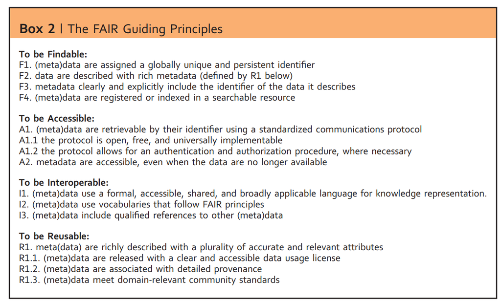

<https://www.nature.com/articles/sdata201618>

## Writing a good data management plan (DMP)

Michener WK (2015) Ten Simple Rules for Creating a Good Data
Management Plan. PLoS Comput Biol 11:e1004525
<http://dx.doi.org/10.1371/journal.pcbi.1004525>.

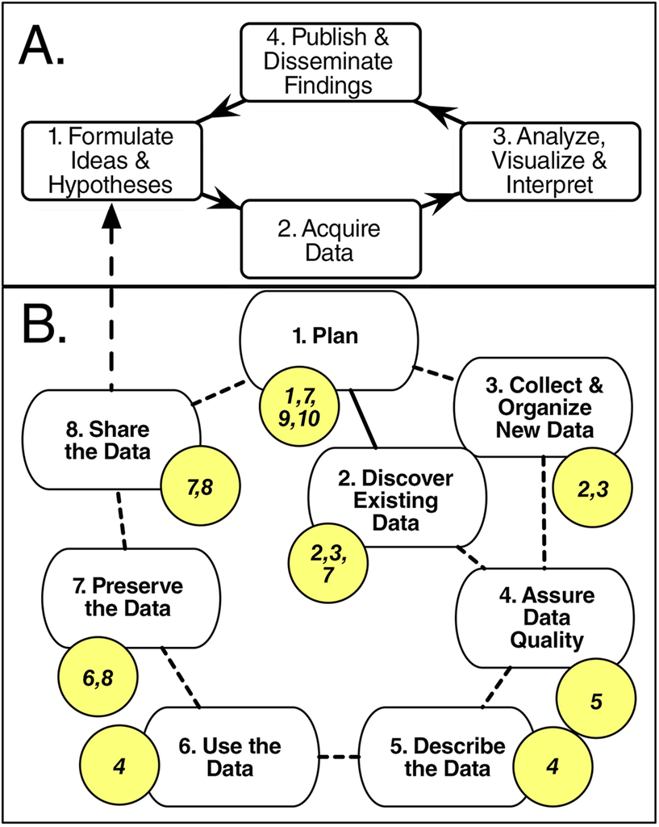

## Things to be wary of

GDPR, Ethics, anonymisation.

## Getting help

* CambridgeData Champions   (phd students, postdocs, faculty)
<https://www.data.cam.ac.uk/data-champions-search>

* Office for Scholarly Communication <https://osc.cam.ac.uk/>

* UK Reproducibility Network  (UKRN)
  <https://www.bristol.ac.uk/psychology/research/ukrn/>

## Losing your data

We all know the stories of PhD students losing their laptop (or in my
case, a server), and along with it their only copy of their data.
Sometimes data comes back though:

[figure not shown]

BACKUP YOUR DATA.

## Licence

What restrictions do you want to put on your data?  If there is no
licence, people cannot easily reuse data.

CC0 <https://wiki.creativecommons.org/wiki/CC0_use_for_data>

## Don't edit the raw data files.

Keep pristine (e.g. read-only) in own folder.  Write scripts to
manipulate your data.

## Open formats

* Data and metadata best stored in open formats
* What does **open** mean?
* Adopt conventions from your field if there any.
* Else use things like HDF5 (matlab), CSV, XML, SQL, JSON (...)
* Spreadsheets better as .csv (not .xls or .xlsx) if used.

## Spot the issues

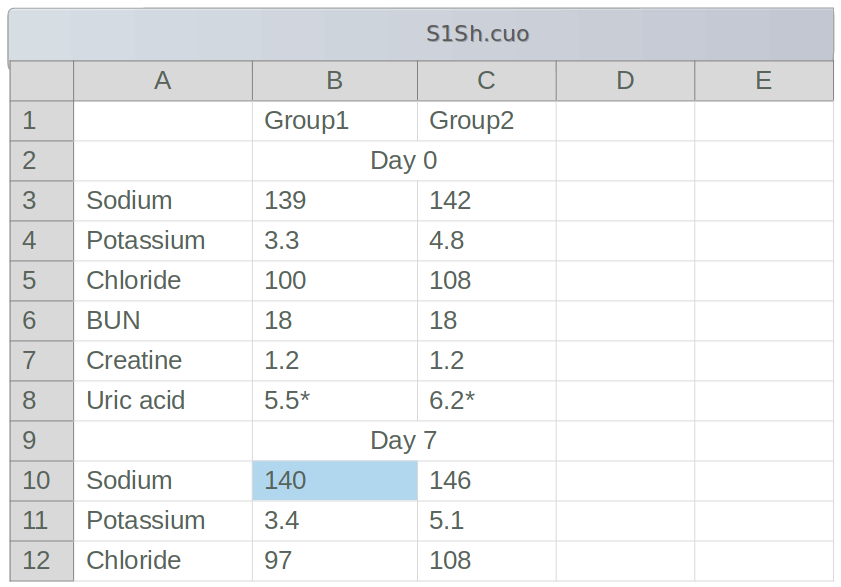

Andrew Hufton/Scientific Data

## A better version

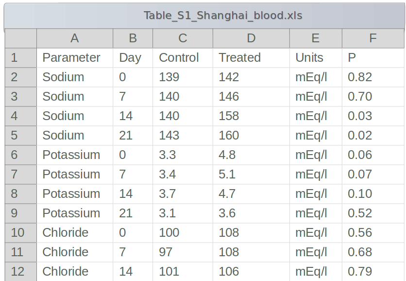

Andrew Hufton/Scientific Data

## Spreadsheet concerns

Ziemann M, Eren Y, El-Osta A (2016) Gene name errors are widespread in
the scientific literature. Genome Biol 17:177
<http://dx.doi.org/10.1186/s13059-016-1044-7>.

> **ABSTRACT** The spreadsheet software Microsoft Excel, when used with default
> settings, is known to convert gene names to dates and floating-point
> numbers. A programmatic scan of leading genomics journals reveals
> that approximately one-fifth of papers with supplementary Excel gene
> lists contain erroneous gene name conversions

> For example, gene symbols such as SEPT2 (Septin 2) and MARCH1
> [Membrane-Associated Ring Finger (C3HC4) 1, E3 Ubiquitin Protein
> Ligase] are converted by default to ‘2-Sep’ and ‘1-Mar’,
> respectively.

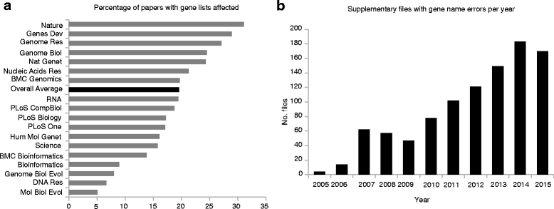

## File names

paper_final_version.docx
    paper_final_version_edits.docx
    paper_final_version_edits2.docx
    paper_final_version_really_final.docx

Opinions vary ...  Little bit of metadata good:

jan15_ctl.txt
	jan15_drug.txt

Some mechanics: avoid spaces, special characters (space, parens,
punctuation)

Learn about regular expressions

## Spreadsheet advice

Broman KW, Woo KH (2018) Data Organization in Spreadsheets. Am Stat
72:2–10 Available at: <https://doi.org/10.1080/00031305.2017.1375989>

## Ten simple rules for the Care and Feeding of Scientific data

Goodman A, Pepe A, Blocker AW, Borgman CL, Cranmer K, Crosas M, Di Stefano R, Gil Y, Groth P, Hedstrom M, Hogg DW, Kashyap V, Mahabal A, Siemiginowska A, Slavkovic A (2014) Ten simple rules for the care and feeding of scientific data. PLoS Comput Biol 10:e1003542 <http://dx.doi.org/10.1371/journal.pcbi.1003542>

1. Love your data, and help others love it, too
2. Share online with permanent identifier
3. Conduct science with a particular level of reuse in mind
4. Publish workflow as a context
5. Link your data to publications as often as possible
6. Publish your code (whatever state is it in)
7. State how you want to get credit
8. Foster/use data repositories
9. Reward colleagues who share data
10. Be a booster for data science

## Find a decent repo

Guidelines from PLOS and Scientific Data

<https://journals.plos.org/plosone/s/data-availability#loc-recommended-repositories>

<https://www.springernature.com/gp/authors/research-data-policy/repositories/12327124>

General repo: Zenodo / figshare

Many universities have own institutional repository, but I find this the wrong
way to cut the cake (prefer by subject, not location)

## Next steps

* Data verification
* Provenance
* Data mining (the robots *are* coming)